# NemaScan Report for tel_estimate_n

16 July, 2021

## Usage

- This R Markdown file imports data tables within Analysis_Results-Date folder and will knit without any modification.
- ggsave code is kept for users to make customized plots.

## Strain Issues

All strain names were converted to the corresponding isotype name, which can be looked up here: https://www.elegansvariation.org/strain/strain_data.tsv. If you submitted replicate data, replicates for a given isotype were averaged to one mean value.

```
## [1] "No strain issues to report"
```

## Manhattan plot

#### Every dot is a SNV marker.

#### SNVs are colored red if they pass the genome-wide corrected significance threshold:

- - If Bonferroni-corrected significance (BF) threshold were used: the horizontal solid line corresponds to BF threshold, and the horizontal dash line corresponds to EIGEN threshold (see below). If user supplied threshold exists, it will replace the BF threshold.
  - If Eigen-decomposition significance threshold were used, the horizontal solid line overlaps with the dash line and corresponds to the EIGEN threshold, which corrects for the number of independent markers in your data set.

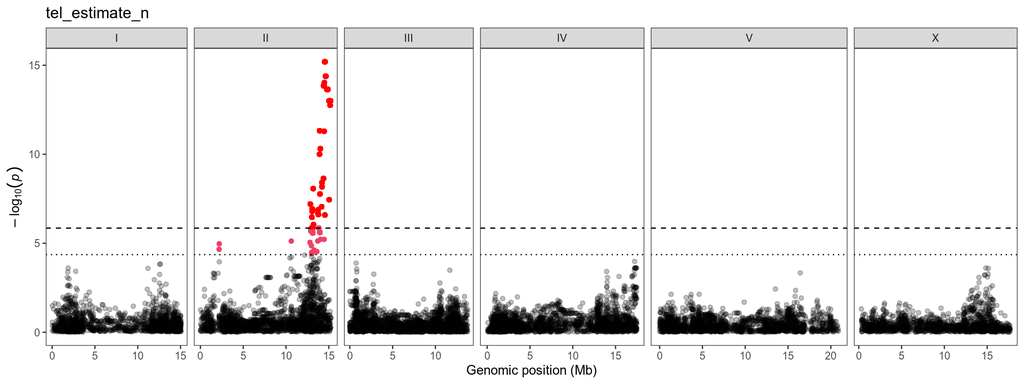

|  | CHROM | marker | trait | startPOS | peakPOS | endPOS | peak_id | narrow_h2 |
| --- | --- | --- | --- | --- | --- | --- | --- | --- |
| 1 | II | II:14518226 | tel_estimate_n | 12278712 | 14518226 | 15257187 | 1 | 0.293832556659027 |

## Phenotype by Genotype Split

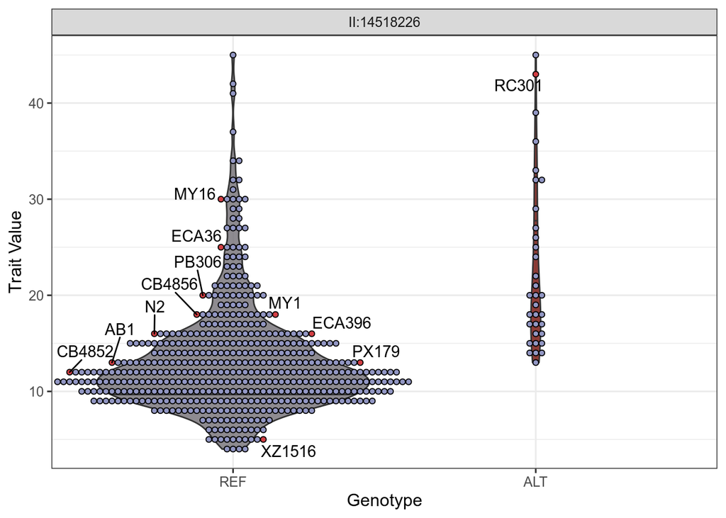

## Linkage disequilibrium (LD) between QTL

```
## [1] "Not enough QTL regions to calculate linkage"
```

## Divergent region, haplotype, and fine mapping for each significant QTL region

Only for regions less than 5 Mb in size

### II:12278712-15257187

#### Fine mapping

Fine mapping was performed by evaluating the genotype-phenotype relationship for variants nearby the QTL identified from GWA mapping using a vcf containing imputed variants to avoid removing variants with missing genotype information for one or a few strains. Only SNVs were considered in this mapping.

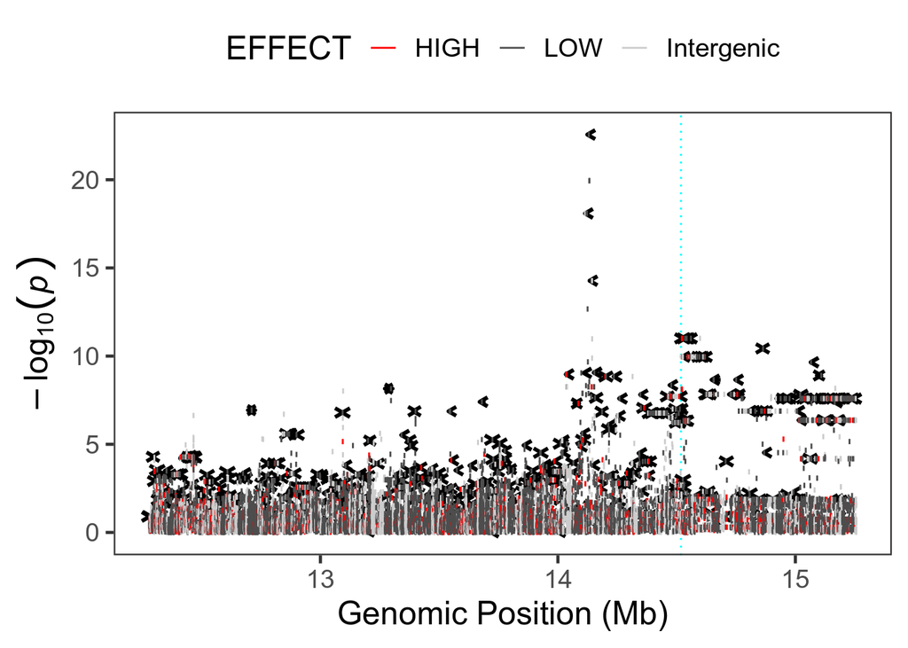

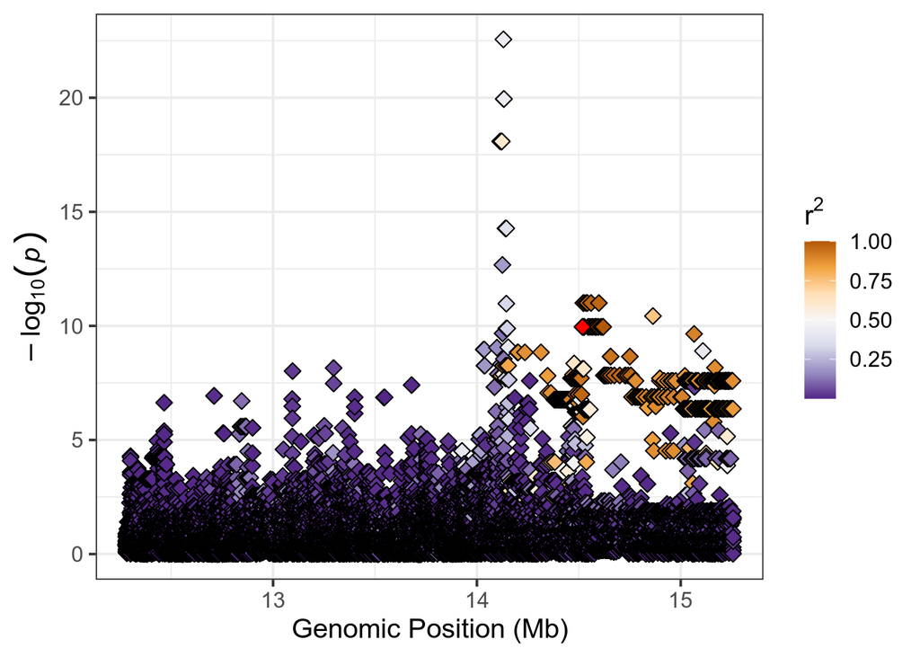

#### Divergent regions

```
## [1] "User-tested strains that do not have divergent region data (shown in blue below): "
```

```
## character(0)
```

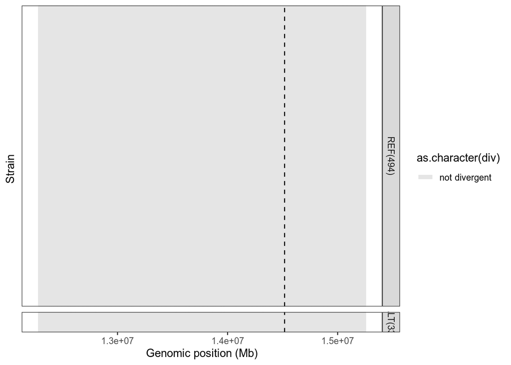

#### Haplotype

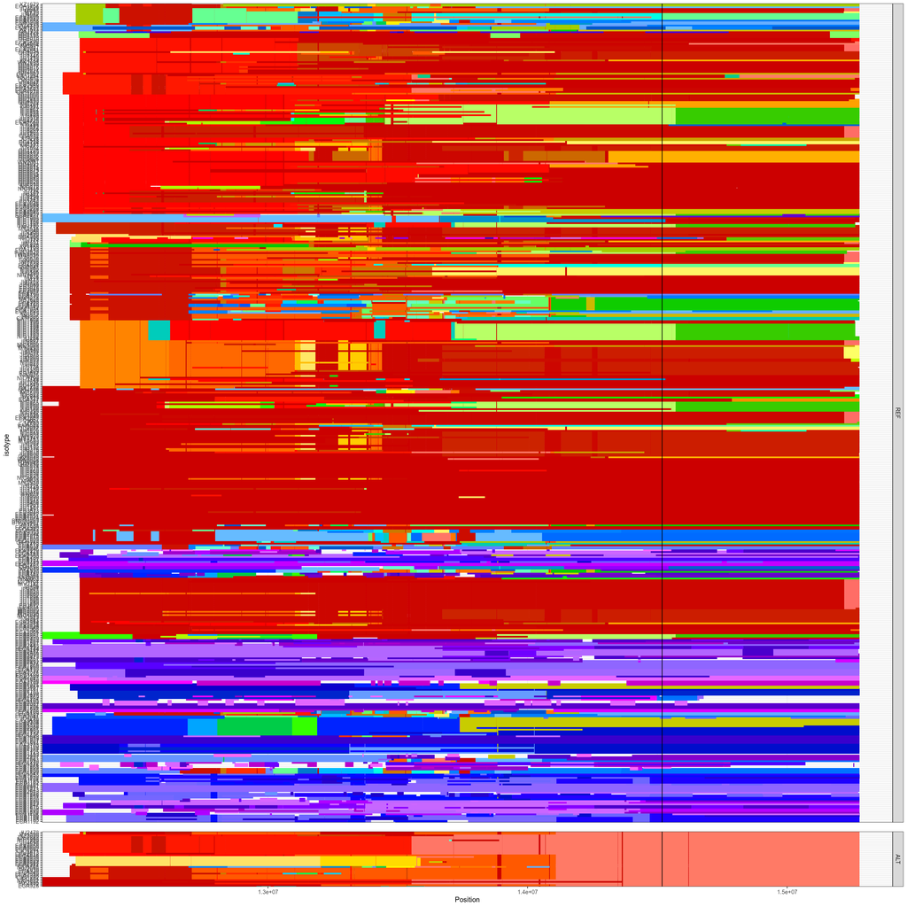